# Table of Contents

```python
import numpy as np
import pandas as pd
import matplotlib.pyplot as plt
import seaborn as sns
import math
import scipy
from statsmodels.stats.weightstats import zconfint
from statsmodels.stats.descriptivestats import sign_test

%matplotlib inline
plt.rcParams["figure.figsize"] = [16, 8]
```

```python
df = pd.read_csv('Transport.csv', sep=';')
df
```

|  | ID | Races | Transport | Fuel |
| --- | --- | --- | --- | --- |
| 0 | 99860714 | 26 | 2 | 307.016361 |
| 1 | 99825350 | 7 | 5 | 102.036736 |
| 2 | 99802757 | 3 | 5 | 7.330508 |
| 3 | 99740533 | 4 | 5 | 38.492241 |
| 4 | 53712113 | 86 | 1 | 561.613191 |
| ... | ... | ... | ... | ... |
| 1099 | 10325660 | 2 | 2 | 61.149487 |
| 1100 | 10766050 | 1 | 3 | 42.669614 |
| 1101 | 10102563 | 1 | 5 | 10.753967 |
| 1102 | 10407523 | 6 | 4 | 91.322470 |
| 1103 | 10158001 | 13 | 3 | 29.090613 |

1104 rows × 4 columns

```python
# create new feature - mean fuel

df['mean_fuel'] = df.Fuel / df.Races
```

На графике ниже видно, что количество представленных в данных грузовиков по видам значительно отличается. (Максимальное отличие между 1-м и 5-м видами. грузовиков 1-го вида в ~6 раз меньше, чем грузовиков 5-го вида)

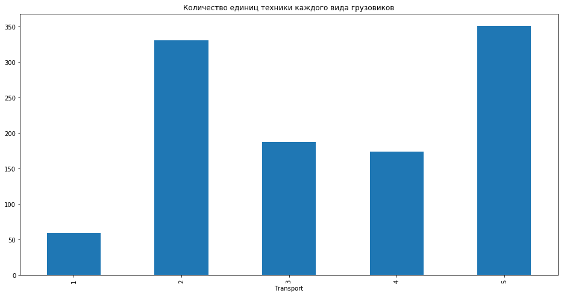

```python
df.groupby('Transport')['ID'].count().plot.bar(title='Количество единиц техники каждого вида грузовиков');
```

На графике ниже можно увидеть, что количество рейсов по видам транспорта не пропорцианально количеству грузовиков. Тем не менее лидеры по количеству грузовиков тамкже имеют наибольшее количество рейсов.

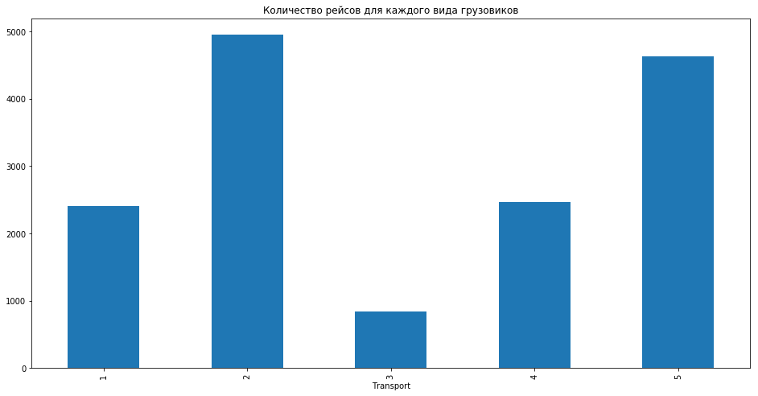

```python
df.groupby('Transport')['Races'].sum().plot.bar(title='Количество рейсов для каждого вида грузовиков');
```

На графике ниже видно, что расход топлива на один рейс по видам транспорта отличается. номера 1 и 4, имеющие не самое большое кол-во рейсов и техники, имеют самый большой расход топлива. Еще предстоит узнать, являются ли эти предположения статистически значимыми, но складывается впечатление, что машины типа 1 и 4 используются для перевозок на большие расстояния.

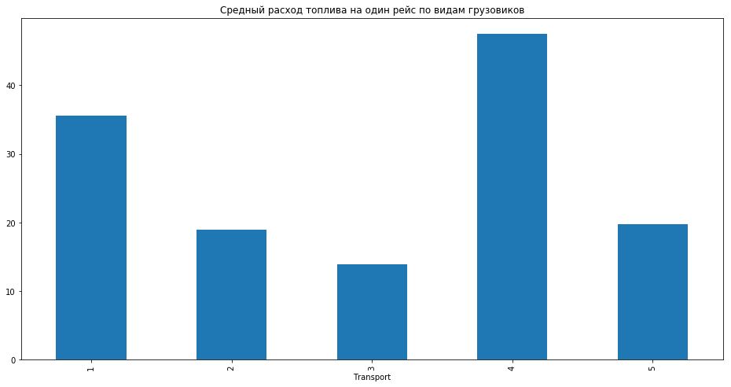

```python
df.groupby('Transport')['mean_fuel'].mean().plot.bar(title='Средный расход топлива на один рейс по видам грузовиков');
```

Ниже приведена сводная таблица с количеством транспорта, количеством рейсов и средним расходом топлива на рейс разделенные по видам транспорта. По значениям в таблице можно заметить, что виды грузовиков 2 и 5 имеют очень похожие показатели по всем трем характеристикам.

```python
df.groupby('Transport').agg({'ID' : 'count', 'Races' : 'sum', 'mean_fuel' : 'mean'})
```

| Transport | ID | Races | mean_fuel |
| --- | --- | --- | --- |
| 1 | 60 | 2410 | 35.556412 |
| 2 | 331 | 4948 | 18.920600 |
| 3 | 188 | 838 | 13.966551 |
| 4 | 174 | 2466 | 47.466740 |
| 5 | 351 | 4634 | 19.774490 |

## Параметрические критерии

Чтобы проверять гипотезы с применением критериев Стьюдента, необходимо чтобы исследуемые выборки не сильно отличались от нормального распределения. Для этого построим Q-Q график и проверим выборки с помощью критерия Шапиро-Уилка.  
*Гипотеза*  
H0: Значения признака Races распределены нормально  
H1: Не нормально  
По результатам проведенных тестов мы во всех случаях отклоняем нулевую гипотезу, следовательно, признаки распределены не нормально.

```
Shapiro normally test. Races. Transport=1.  W-statistic: 0.8603485226631165, p-value: 6.238728019525297e-06
Shapiro normally test. Races. Transport=2.  W-statistic: 0.687035858631134, p-value: 2.4712625856336006e-24
Shapiro normally test. Races. Transport=3.  W-statistic: 0.1488131284713745, p-value: 2.2023524100328166e-28
Shapiro normally test. Races. Transport=4.  W-statistic: 0.4907658100128174, p-value: 3.3888432027141914e-22
Shapiro normally test. Races. Transport=5.  W-statistic: 0.7628263235092163, p-value: 3.7420703773941727e-22
```

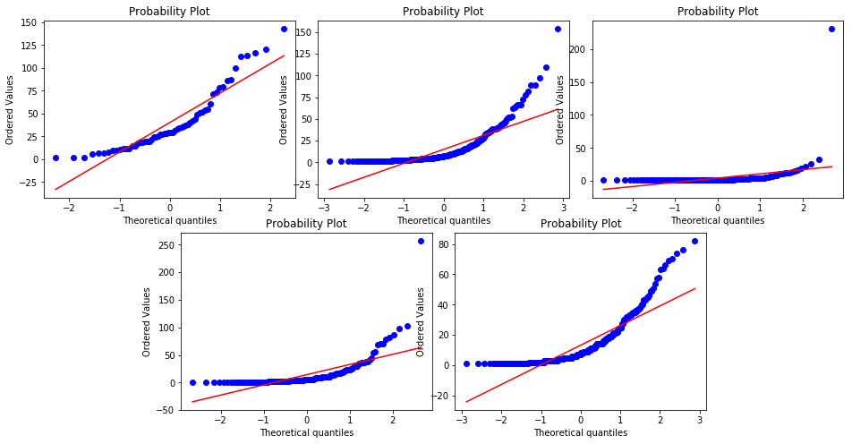

```python
ax1 = plt.subplot2grid(shape=(2,6), loc=(0,0), colspan=2)
ax2 = plt.subplot2grid((2,6), (0,2), colspan=2)
ax3 = plt.subplot2grid((2,6), (0,4), colspan=2)
ax4 = plt.subplot2grid((2,6), (1,1), colspan=2)
ax5 = plt.subplot2grid((2,6), (1,3), colspan=2)

plots = [ax1, ax2, ax3, ax4, ax5]

for i in range(1, 6):
    shapiro_races = scipy.stats.shapiro(df[df.Transport == i].Races)
    print(f"Shapiro normally test. Races. Transport={i}.  W-statistic: {shapiro_races[0]}, p-value: {shapiro_races[1]}")
    scipy.stats.probplot(df[df.Transport == i].Races, dist='norm', plot=plots[i-1]);
```

*Гипотеза*  
H0: Значения признака mean_fuel распределены нормально  
H1: Не нормально  
По результатам проведенных тестов мы во всех случаях отклоняем нулевую гипотезу, следовательно, признаки распределены не нормально.

```
Shapiro normally test. Races. Transport=1.  W-statistic: 0.4989572763442993, p-value: 5.288951243111184e-13
Shapiro normally test. Races. Transport=2.  W-statistic: 0.5711323022842407, p-value: 9.550002889086045e-28
Shapiro normally test. Races. Transport=3.  W-statistic: 0.5525674819946289, p-value: 9.340084845041937e-22
Shapiro normally test. Races. Transport=4.  W-statistic: 0.4899711608886719, p-value: 3.2735140102902865e-22
Shapiro normally test. Races. Transport=5.  W-statistic: 0.5793170928955078, p-value: 2.905896063164932e-28
```

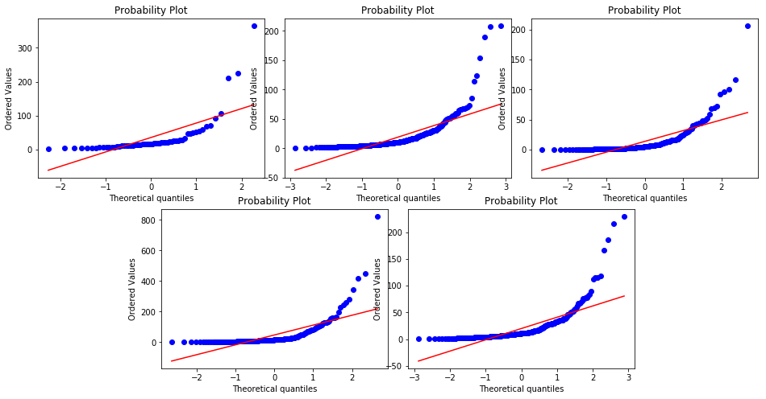

```python
ax1 = plt.subplot2grid(shape=(2,6), loc=(0,0), colspan=2)
ax2 = plt.subplot2grid((2,6), (0,2), colspan=2)
ax3 = plt.subplot2grid((2,6), (0,4), colspan=2)
ax4 = plt.subplot2grid((2,6), (1,1), colspan=2)
ax5 = plt.subplot2grid((2,6), (1,3), colspan=2)

plots = [ax1, ax2, ax3, ax4, ax5]

for i in range(1, 6):
    shapiro_races = scipy.stats.shapiro(df[df.Transport == i].mean_fuel)
    print(f"Shapiro normally test. Races. Transport={i}.  W-statistic: {shapiro_races[0]}, p-value: {shapiro_races[1]}")
    scipy.stats.probplot(df[df.Transport == i].mean_fuel, dist='norm', plot=plots[i-1]);
```

Увы, оценка критерием Шапиро-Уилка подвержена неточности при наличие в данных выбросов (экстримальных отклонений от среднего). Исключим из выборок все значения, превышающие 95-персентиль и меньше 5-персентиля.  
На новых данных построим Q-Q график и проверим на нормальность тем же методом.

```
Shapiro normally test. mean_fuel. Transport=1.  W-statistic: 0.7666569352149963, p-value: 7.116079103752782e-08
Shapiro normally test. mean_fuel. Transport=2.  W-statistic: 0.8200931549072266, p-value: 7.077834604217148e-18
Shapiro normally test. mean_fuel. Transport=3.  W-statistic: 0.7439128160476685, p-value: 8.397050534693666e-16
Shapiro normally test. mean_fuel. Transport=4.  W-statistic: 0.7200143337249756, p-value: 6.735242831190061e-16
Shapiro normally test. mean_fuel. Transport=5.  W-statistic: 0.8188048005104065, p-value: 1.6952069901636176e-18
```

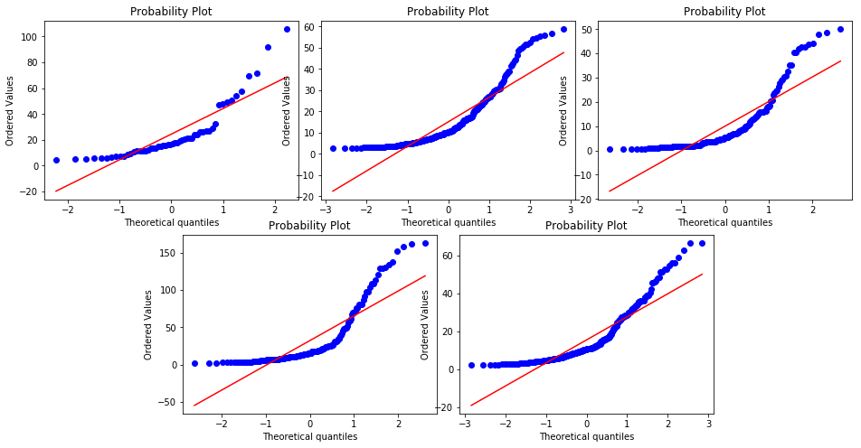

```python
ax1 = plt.subplot2grid(shape=(2,6), loc=(0,0), colspan=2)
ax2 = plt.subplot2grid((2,6), (0,2), colspan=2)
ax3 = plt.subplot2grid((2,6), (0,4), colspan=2)
ax4 = plt.subplot2grid((2,6), (1,1), colspan=2)
ax5 = plt.subplot2grid((2,6), (1,3), colspan=2)

plots = [ax1, ax2, ax3, ax4, ax5]

for i in range(1, 6):
    q1 = df[df.Transport == i].mean_fuel.quantile(0.05)
    q2 = df[df.Transport == i].mean_fuel.quantile(0.95)

    shapiro_mean_fuel = scipy.stats.shapiro(df[(df.Transport == i) & (df.mean_fuel > q1) & (df.mean_fuel < q2)].mean_fuel)
    print(f"Shapiro normally test. mean_fuel. Transport={i}.  W-statistic: {shapiro_mean_fuel[0]}, p-value: {shapiro_mean_fuel[1]}")
    scipy.stats.probplot(df[(df.Transport == i) & (df.mean_fuel > q1) & (df.mean_fuel < q2)].mean_fuel, dist='norm', plot=plots[i-1]);
```

Даже после очистки данных, мы не можем считать наши выборки распределенными нормально. Также кретерий Колмогорова-Смирнова это подтвержает (не рассписывал). Следовательно, использование параметрических методов оценки среднего (в частности, критерий Стьюдента) мы не можем использовать.

## Непараметрические критерии

Просто построив 95% интервал среднего расхода топлива на рейс можно отличать некоторые типы грузовиков.

```
Transport 1. Среднее: 35.556411748136775. 95% интервал: (20.3979545187128, 50.71486897756075)
Transport 2. Среднее: 18.920600350483774. 95% интервал: (16.117811641584648, 21.723389059382892)
Transport 3. Среднее: 13.966550672121652. 95% интервал: (10.530560044557634, 17.40254129968567)
Transport 4. Среднее: 47.466739910853164. 95% интервал: (33.77765803166177, 61.15582179004457)
Transport 5. Среднее: 19.77448971420881. 95% интервал: (16.87596294364389, 22.673016484773726)
```

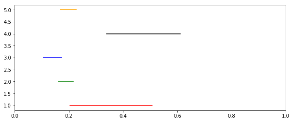

```python
colors = ['red', 'green', 'blue', 'black', 'orange']
plt.rcParams["figure.figsize"] = [10, 4]
for i in range(1, 6):
    s, f = zconfint(df[df.Transport == i].mean_fuel)
    print(f'Transport {i}. Среднее: {df[df.Transport == i].mean_fuel.mean()}. 95% интервал:', zconfint(df[df.Transport == i].mean_fuel))
    plt.axhline(y=i, xmin=s/100, xmax=f/100, c=colors[i-1])
```

Сделаем тоже самое по кол-ву рейсов.

```
Transport 1. Среднее: 35.556411748136775. 95% интервал: (31.60420224420752, 48.72913108912581)
Transport 2. Среднее: 18.920600350483774. 95% интервал: (12.86147487806913, 17.035806088698244)
Transport 3. Среднее: 13.966550672121652. 95% интервал: (2.0021142494853947, 6.912779367535881)
Transport 4. Среднее: 47.466739910853164. 95% интервал: (10.23687684844994, 18.10795073775696)
Transport 5. Среднее: 19.77448971420881. 95% интервал: (11.660830324210274, 14.74372808034813)
```

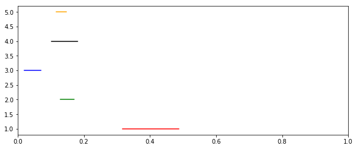

```python
colors = ['red', 'green', 'blue', 'black', 'orange']
plt.rcParams["figure.figsize"] = [10, 4]
for i in range(1, 6):
    s, f = zconfint(df[df.Transport == i].Races)
    print(f'Transport {i}. Среднее: {df[df.Transport == i].mean_fuel.mean()}. 95% интервал:', zconfint(df[df.Transport == i].Races))
    plt.axhline(y=i, xmin=s/100, xmax=f/100, c=colors[i-1])
```

## Корреляция Races и Fuel

1) Посчитаем коэффициент корреляции Пирсона 2) Используем критерий Стьюдента для проверки гипотезы о зависимости данных признаков.  
*Гипотеза*  
H0: Коэффициент корреляции равен 0  
H1: Не равен 0

```python
df[['Races', 'Fuel']].corr()
```

|  | Races | Fuel |
| --- | --- | --- |
| Races | 1.000000 | 0.498301 |
| Fuel | 0.498301 | 1.000000 |

```python
# расчет доверительного интервала коэфф. корреляции

def r_to_z(r):
    return math.log((1 + r) / (1 - r)) / 2.0

def z_to_r(z):
    e = math.exp(2 * z)
    return((e - 1) / (e + 1))

def r_confidence_interval(r, alpha, n):
    z = r_to_z(r)
    se = 1.0 / math.sqrt(n - 3)
    z_crit = scipy.stats.norm.ppf(1 - alpha/2)

    lo = z - z_crit * se
    hi = z + z_crit * se

    # Return a sequence
    return (z_to_r(lo), z_to_r(hi))
```

```python
r, p = scipy.stats.pearsonr(df.Races, df.Fuel)
print(f"Для признаков Races и Fuel коэффициент корреляции Пирсона: {r}. P-value равно {p}")
print("95% Доверительный интервал коэффициента корреляции:", r_confidence_interval(r, 0.05, df.shape[0]))
```

```
Для признаков Races и Fuel коэффициент корреляции Пирсона: 0.498300705436121. P-value равно 2.4070203004337987e-70
95% Доверительный интервал коэффициента корреляции: (0.4526074866938789, 0.5413839331892549)
```

Исходя из полученный рассчетов, мы с уверенность 95% отклоняем нулевую гипотезу (r == 0). Построенный доверительный интервал не включает в себя 0.  
Следовательно, мы можем утверждать, что Races и Fuel зависимы.